```python
import pandas as pd
import numpy as np
from dateutil import parser
import plotly.express as px
import matplotlib.pyplot as plt
```

# CAIC Avalanche Data Analysis

This analysis was conducted with my colleagues, Jackson Patrick and Aaron Graff, in the Spring of 2024.

**The file includes all my individual contributions to the project. All code presented here was written by me.**

You can find the full report, which encompasses an analysis of avalanche frequencies over time and correlations with evolving weather patterns, in the following GitHub repository: [AvalancheAnalysis](https://github.com/TrevorChartier/AvalancheAnalysis.git).

## Introduction

The purpose of this analysis is to investigate the trends of avalanche frequencies in CO acrosss geographic features, and area. I aim to find out what kinds of geographic features make for dangerous avalanche conditions, and what parts of CO are especially prone to avalances.

We utilize publicly available data from CAIC that can be generated here: https://avalanche.state.co.us/observations/avalanches.

## Data Pre-Processing

#### Reading In Data

```python
avalanches_data = pd.read_csv("avalanche-record-CAIC.csv")
avalanches_data.head(3)
```

|  | Observation ID | Date | Date Known | Landmark | First Name | Longitude | latitude | Last Name | # | Elev | ... | Status | Locked | Weak Layer | Avg Width | Width Units | Avg Vertical | Vertical Units | Avg Crown | Crown Units | Terminus |
| --- | --- | --- | --- | --- | --- | --- | --- | --- | --- | --- | --- | --- | --- | --- | --- | --- | --- | --- | --- | --- | --- |
| 0 | - | Thu Apr 11 2024 12:00:00 GMT-0600 (Mountain D... | Estimated | - | Mac | -106.1225117 | 39.4264253 | Peters | 1 | >TL | ... | approved | - | - | - | ft | - | ft | - | in | - |
| 1 | - | Thu Apr 11 2024 00:12:12 GMT-0600 (Mountain D... | Known | - | Scott | -105.6973734 | 40.3163493 | Eubank | 2 | >TL | ... | approved | - | - | - | ft | - | ft | - | in | - |
| 2 | - | Thu Apr 11 2024 00:00:00 GMT-0600 (Mountain D... | Estimated | - | Scott | -105.6527821 | 40.3091512 | Eubank | 2 | >TL | ... | approved | - | - | - | ft | - | ft | - | in | - |

3 rows × 32 columns

#### Removing Unecessary Columns

Trevor Chartier

```python
avalanches_data = avalanches_data.drop(columns  = ["Date Known","Observation ID","Comments","Description","Secondary Trigger",
                                                   "Location","Landmark", "Area", "First Name","Last Name", "Status","Locked",
                                                   "Weak Layer", "Avg Width", "Width Units","#", "Avg Vertical","Vertical Units",
                                                   "Avg Crown", "Crown Units", "Terminus", 'Sliding Sfc','Incident','sizeR'])
avalanches_data.head()
```

|  | Date | Longitude | latitude | Elev | Asp | Type | Trig | sizeD |
| --- | --- | --- | --- | --- | --- | --- | --- | --- |
| 0 | Thu Apr 11 2024 12:00:00 GMT-0600 (Mountain D... | -106.1225117 | 39.4264253 | >TL | E | L | AO | D1 |
| 1 | Thu Apr 11 2024 00:12:12 GMT-0600 (Mountain D... | -105.6973734 | 40.3163493 | >TL | SE | SS | AS | D1 |
| 2 | Thu Apr 11 2024 00:00:00 GMT-0600 (Mountain D... | -105.6527821 | 40.3091512 | >TL | E | SS | N | D1 |
| 3 | Thu Apr 11 2024 00:00:00 GMT-0600 (Mountain D... | -108.0197277 | 37.4168616 | >TL | W | WL | N | D1 |
| 4 | Wed Apr 10 2024 18:14:49 GMT-0600 (Mountain D... | -106.9405172 | 39.1316096 | >TL | E | WS | N | D2 |

#### A Note on Missing Values

```python
# Missing values are represented by the string ' -' in the data. Replace them with NaN
avalanches_data.replace(' -',np.nan,inplace=True)
print(avalanches_data.isna().sum())
```

```
Date            0
Longitude      29
latitude       29
Elev          659
Asp           656
Type         1953
Trig          819
sizeD         912
dtype: int64
```

As you might expect, not every entry (avalanche report) has available data for all features. We don't want to remove all NA values before investigating trends of avlanche frequencies because this may add the confounding variable of report quality to interfere with our analysis. We don't want avalanches with better report quality to be disproportionally represented over those with some missing values. Instead, we will deal with missing values on a case by case basis to include as many valid reports as possible.

#### Converting Longitude/Latitude Columns to Correct Data-Type

```python
avalanches_data["Longitude"] = avalanches_data["Longitude"].astype(float)
avalanches_data["latitude"] = avalanches_data["latitude"].astype(float)
```

#### Remove Reports From Far Outside Colorado

```python
avalanches_data = avalanches_data[(avalanches_data['Longitude']< -101) & (avalanches_data['Longitude']> -110) &
                               (avalanches_data['latitude']>36) & (avalanches_data['latitude']<42)]
```

The general region of Colorado includes approximately:

Latitudes from 37 degrees to 41 degrees  
Longitudes from -102 degrees to -109 degrees

Some entries have erroneous coordinates far outside this region, so we will remove these entries.

#### Simplifying Trigger Column

```python
def codeTrig(x):
    if x == 'N':
        return "Natural"
    if x == 'A':
        return "Artificial"

# Extract first letter from Trig column and apply the codeTrig function
# All values in the data are padded with a leading space, to extract the first letter, we want index 1, not 0
avalanches_data['Trig'] = avalanches_data['Trig'].str[1:2].apply(codeTrig)

avalanches_data.head(3)
```

|  | Date | Longitude | latitude | Elev | Asp | Type | Trig | sizeD |
| --- | --- | --- | --- | --- | --- | --- | --- | --- |
| 0 | Thu Apr 11 2024 12:00:00 GMT-0600 (Mountain D... | -106.122512 | 39.426425 | >TL | E | L | Artificial | D1 |
| 1 | Thu Apr 11 2024 00:12:12 GMT-0600 (Mountain D... | -105.697373 | 40.316349 | >TL | SE | SS | Artificial | D1 |
| 2 | Thu Apr 11 2024 00:00:00 GMT-0600 (Mountain D... | -105.652782 | 40.309151 | >TL | E | SS | Natural | D1 |

From the data source (Colorado Avalanche Information Center) the trigger column (labeled 'Trig') contains tages such as N, AS, AX, etc.

The first letter of each tag indicates whether the avalnche was triggered Naturally (N) or Artificially (A). The second letter indicates if the artificial trigger was from a skier, explosive, etc.

To simplify this analysis, and because we were unable to recieve confirmation from CAIC about what every trigger label meant, we only separate natural vs artificial triggers

## Comparing Avalanche Frequencies for Different Geographic Features

#### Elevation

```python
# Count frequencies for each elevation type (Relative to Tree Line)
elevations = pd.DataFrame(avalanches_data.groupby("Elev")['Asp'].count()).sort_values(by='Asp')

# Rename frequency column to be descriptive of content
elevations = elevations.rename(columns={"Asp": "Frequency"})

# We don't want frequencies for avalanches with All, Unknown, or Missing Values for elevations. Filter them out.
elevations = elevations.loc[(" <TL"," TL", " >TL"),:]

# Provide descriptive names for indexes
elevations.index = ["Below Tree Line", "Tree Line", "Above Tree Line"]
```

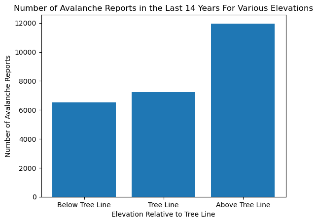

```python
# Create barplot of elevation frequencies
plt.bar(elevations.index, elevations['Frequency'])
plt.xlabel('Elevation Relative to Tree Line')
plt.ylabel('Number of Avalanche Reports')
plt.title('Number of Avalanche Reports in the Last 14 Years For Various Elevations');
```

From the plot, it is clear that the avlanche frequency is increasing with elevation; this follows the expected trends. Higher elevations see more snowfall, and above tree line there is more exposure to the sun, wind, and nothing to help hold the snow in place. These are all factors that correlate with the shown increase in slide frequencies.

#### Slope Aspect

Slope aspect refers to the direction in which the slope faces. You have probably heard about the brand "The North Face" This company name refers to the face of the slope that receives the least amount of sunlight. How will the direction in which the slope faces impact avalanche danger?

##### Prepare data for our visualization

```python
# Count number of avalanche reports for each slope aspect
aspects = pd.DataFrame(avalanches_data.groupby("Asp")['Elev'].count())

# Rename frequency column to be more descriptive
aspects = aspects.rename(columns={"Elev": "Frequency"})

# We don't care about frequencies for the avalanches wit unknown or missing slope aspects. Filter them out.
aspects = aspects.loc[(" SW"," S"," W"," NW"," SE"," N"," NE"," E"),:]

# Arrange the frequencies in their natural order according to compass direction
order = [" N", " NE", " E", " SE", " S", " SW", " W", " NW"]
aspects = aspects.reindex(order)
aspects
```

| Asp | Frequency |
| --- | --- |
| N | 3872 |
| NE | 5601 |
| E | 6879 |
| SE | 3685 |
| S | 1381 |
| SW | 832 |
| W | 1701 |
| NW | 1774 |

##### Now, we can create the figure

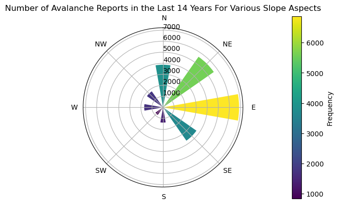

```python
angles = np.radians(np.arange(0, 360, 45))  # 8 directions evenly spaced (for the 8 aspects)
frequencies = aspects['Frequency'].tolist()

# Create a polar plot
fig, ax = plt.subplots(subplot_kw={'projection': 'polar'})
ax.set_theta_direction(-1)  # Counter-clockwise direction
ax.set_theta_offset(np.pi/2)  # Start angle at 90 degrees (North)

# For coloring the bars based on frequencies
cmap = plt.colormaps['viridis']
norm = plt.Normalize(min(frequencies), max(frequencies))

# Plot the frequencies on the polar plot
bars = ax.bar(angles, frequencies, width=0.35, bottom=0, color=cmap(norm(frequencies)))


# Set the labels for each direction
ax.set_xticks(angles)
ax.set_xticklabels(aspects.index)

ax.set_rlabel_position(0)


ax.set_title("Number of Avalanche Reports in the Last 14 Years For Various Slope Aspects")

# Color bar legend
colorMap = plt.cm.ScalarMappable(cmap=cmap, norm=norm)
colBar = plt.colorbar(colorMap, ax=ax, pad=0.2)
colBar.set_label('Frequency')

plt.show()
```

The results of this analysis were somewhat suprising. Personally, I had expected the Northern facing slopes to have the greatest frequency of avalanches because the lack of sunlight on this slope leads to greater snowpack retention. This is likely the reason that the sunnier Southern and South-West facing slopes have relatively few avalanches, but what makes the Eastern facing slopes so avlanche prone?

After some research, we found that this pattern can be explained by wind patterns. In Colorado, the prevailing winds typically travel from West to East. This makes the Eastern slopes the leeward slopes (the slopes oriented away from the wind). These eastern leeward slopes are succeptible to becoming wind loaded as snow blows onto them from the Western, windward slopes. This windloading is what makes them especially dangerous for avalanches.

To test this theory against our data, we should expect Eastern slopes to have a greater proportion of Cornice type avalanches as these formations are impacted by wind...

## Comparing Avalanche Types on Eastern and Western Slopes

In order to see what is causing the great disparity in avalanche frequencies between Eastern and Western slopes, I have chosen to isolate Eastern and Western slope aspects and investigate the distribution of avalanche types for each aspect.

#### Prepare Data

```python
def calcPrecentageWest(type):
    return len(type)/len(western_slope) * 100

def calcPercentageEast(type):
    return len(type)/len(eastern_slope) * 100

western_slope = avalanches_data[avalanches_data['Asp'] == ' W'] # Only avalanches with Western aspect
eastern_slope = avalanches_data[avalanches_data['Asp'] == ' E'] # Only avalances with Eastern aspect

# Calculate percentage of avalanches for each type for western slope
west = pd.DataFrame(western_slope.groupby('Type').apply(calcPrecentageWest))

# Avalanche code abbreviations can be found here: https://www.americanavalancheassociation.org/swag
west.index = ['Cornice','Glide','Hard Slab','Loose','Roof', 'Soft Slab', 'Unknown', 'Wet-Loose','Wet Slab']
west.columns = ['Western']

# Repeat for Eastern Slope
east = pd.DataFrame(eastern_slope.groupby('Type').apply(calcPercentageEast))
east.index = ['Cornice','Glide','Hard Slab','Loose', 'Roof', 'Slush Flow', 'Soft Slab', 'Unknown', 'Wet-Loose','Wet Slab']
east.columns= ['Eastern']

# Merge into one dataframe
avalancheTypePercentage = pd.merge(east, west,left_index=True, right_index=True, how='outer')
avalancheTypePercentage.fillna(0, inplace=True)

avalancheTypePercentage
```

|  | Eastern | Western |
| --- | --- | --- |
| Cornice | 1.306720 | 0.057670 |
| Glide | 0.186674 | 0.115340 |
| Hard Slab | 15.939115 | 11.649366 |
| Loose | 4.092476 | 5.190311 |
| Roof | 0.014360 | 0.115340 |
| Slush Flow | 0.014360 | 0.000000 |
| Soft Slab | 58.242389 | 54.671280 |
| Unknown | 2.527283 | 1.499423 |
| Wet Slab | 3.403217 | 8.650519 |
| Wet-Loose | 7.021827 | 13.610150 |

#### Plot Data

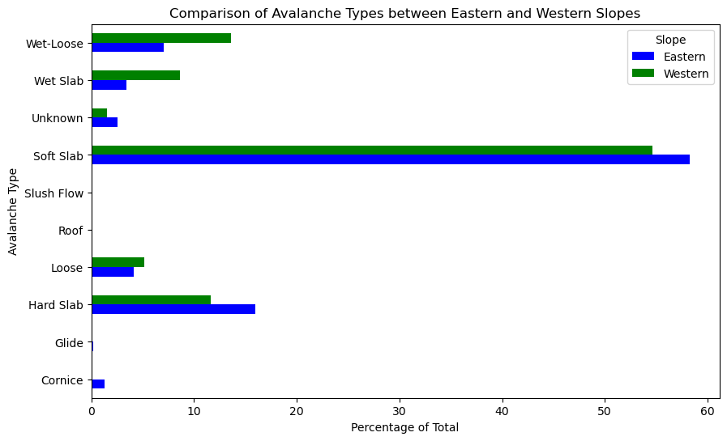

```python
ax = avalancheTypePercentage.plot(kind='barh', figsize=(10, 6), color=['blue', 'green'])
ax.set_xlabel('Percentage of Total')
ax.set_ylabel('Avalanche Type')
ax.set_title('Comparison of Avalanche Types between Eastern and Western Slopes')
plt.legend(title='Slope', labels=['Eastern', 'Western'])
plt.show()
```

It should be made explicit that the x-axis is a measurement of the percentage of the total avalanches for the given slope aspect, NOT the total number of avalanches.

As we expected, Cornice avalanches make up over a 22 times greater percentage of the total avalanches on Eastern slopes (1.3%) than they do on Western slopes (.058%). However, from the figure, we see that cornice avalances still make up a relatively small portion of total avalanches.

Although this visualization only shows East and West slope aspects for ease of direct comparison, it still provides us some interesting insight on the distribution of different avalanche types with soft slabs being by far the most common. In case your interested, an example of this avalanche type can be seen here: https://www.youtube.com/watch?v=yjDoE3trvOM

## Investigating Avalanche Spatial Distributions Across the State of Colorado

#### Preparing Data

```python
# Each point will also include information on size, aspect, trigger, and elevation when hovered over
# We only want to plot points that have all of this information
map_avalanche_data = avalanches_data.dropna(subset = ['sizeD','Asp','Elev','Trig'])


# Remove Entries With Unknown Destructive Size
validCodes = [' D1',' D2',' D1.5',' D3.5',' D3',' D4',' D5']
mask = map_avalanche_data['sizeD'].isin(validCodes)
map_avalanche_data = map_avalanche_data[mask]

# Extract Destructive Sizes Into Numeric Column
map_avalanche_data['Destructive Size'] = map_avalanche_data['sizeD'].str[2:].astype(float)
```

```python
# Define a custom color scale
custom_color_scale = [
    (0.0, 'rgb(15, 4, 135)'),    # Dark blue
    (0.05, 'rgb(63, 13, 207)'),
    (0.1, 'rgb(100, 21, 255)'),
    (0.15, 'rgb(136, 35, 255)'), # Purplish
    (0.20, 'rgb(170, 58, 252)'),
    (0.25, 'rgb(200, 18, 240)'),
    (0.35, 'rgb(190, 18, 190)'),
    (0.50, 'rgb(239, 100, 100)'),
    (0.68, 'rgb(242, 82, 24)'),  # Orange towards the higher end
    (0.80, 'rgb(253, 200, 8)'),
    (1.0, 'rgb(255, 255, 0)')      # Bright yellow
]
```

Points representing avalanche reports will be colored based on their size. There are far more D1 - D3 Avalanches than the extremely large D4-D5 avlanches. By defining a custom color scale, I am able to make the differences in color between the more common D1-D3 avalanches more easy to dstinguish than by using a uniform color distribution. Additionally, I can take care to avoid common accessibility issues with regards to colorblindness, such as red and green.

#### Plot Data

```python
# Plot Avalanche reports over a map
# Size and color of points is dependent on avalanche size
fig = px.scatter_mapbox(map_avalanche_data,
                        lat="latitude",
                        lon="Longitude",
                        color="Destructive Size", # Color of point is mapped based on avalanche size
                        hover_name= "sizeD",
                        hover_data= {"Trig":True,"Asp":True,"Elev":True,"sizeD":False,"latitude": False,
                                     "Longitude":False,'Destructive Size':False}, # What data appears when point is hovered over
                        size ="Destructive Size", # Size of point is proportional to avalanche size
                        size_max = 12,
                        zoom=8,
                        mapbox_style="open-street-map",
                        height=800,
                        width=800,
                        color_continuous_scale=custom_color_scale,
                        opacity= 0.5)

# Customize margins of figure
fig.update_layout(margin={"r":0,"t":20,"l":0,"b":0})
fig.write_html('plotlyplot.html')
```

### Distribution of avalanches in Colorado, coded by destructive size

[interactive chart not shown]

Destructive size ranges from 1 to 5 with 1 being relatively harmless and 5 being the largest avalanches known.

Looking at the map, we see a prevelance of avalanches throughout the Rocky Mountain Range in CO.